# improved output semantic for python objects

**title**

improved output semantic for python objects

**description**

when we provide the right semantics to the outputs we increase the tactile representation on assistive techonology. these improvements make it easier for screen reader users to surface lists, tables, and links created from python.

**language**

python

In [ ]

markdown

actions

```
# improved output semantic for python objects

when we provide the right semantics to the outputs we increase the tactile representation on assistive techonology. these improvements make it easier for screen reader users to surface lists, tables, and links created from python.

we use the `itemscope` and `itemtype` properties as the proper semantic attributes to provide type information. these types extend to css selectors that can tailor specific type representations.
```

5

# improved output semantic for python objects

when we provide the right semantics to the outputs we increase the tactile representation on assistive techonology. these improvements make it easier for screen reader users to surface lists, tables, and links created from python.

we use the `itemscope` and `itemtype` properties as the proper semantic attributes to provide type information. these types extend to css selectors that can tailor specific type representations.

In [ ]

markdown

actions

```
![list of lists, sets, tuples found on this page by the orca screen reader](attachment:433375f5-8127-4e69-9797-e3dd61140691.png)
![list of tables found on this page by the orca screen reader](attachment:4e8c0c77-3589-41a5-aae8-03796470919b.png)
```

2

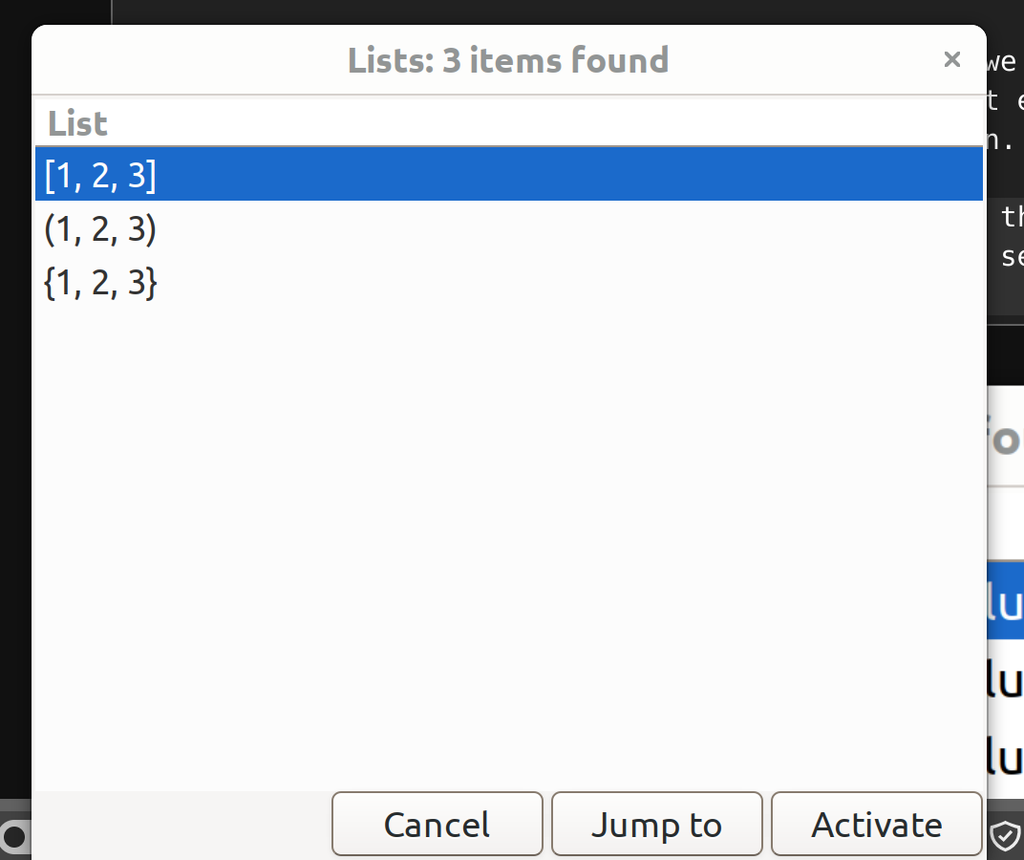

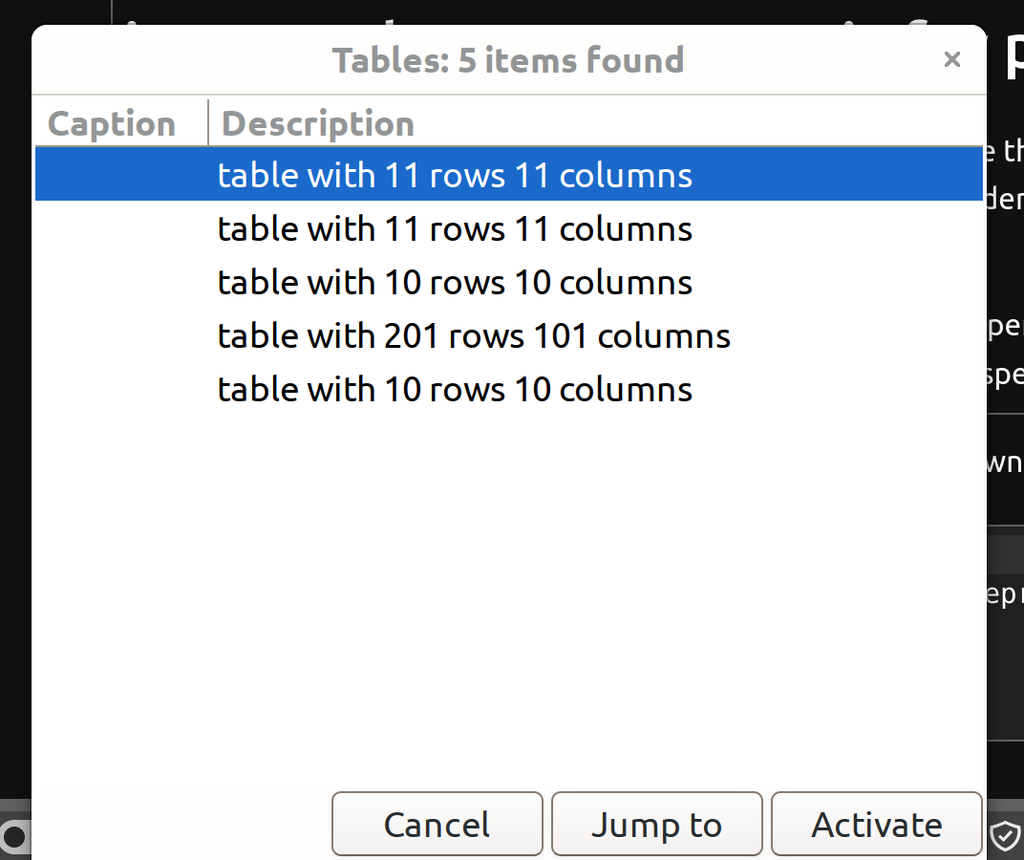

In [ ]

markdown

actions

```
itemscope indicates that representation was generated for known type
```

1

itemscope indicates that representation was generated for known type

In [ 1 ]

code

actions

```
    import nbconvert_a11y.tables
    from nbconvert_a11y.outputs import repr_html, repr_semantic
    import pandas
    %reload_ext nbconvert_a11y.tables
    %reload_ext nbconvert_a11y.outputs
```

5

In [ ]

markdown

actions

```
comparing the standard dict repr with the semantic repr
```

1

comparing the standard dict repr with the semantic repr

In [ 2 ]

code

actions

```
    data = {'a': 1, 'b': 'abc', 'd': True, 'e': False}
    data["f"] = data
    print(repr(data))
    data
```

4

```
{'a': 1, 'b': 'abc', 'd': True, 'e': False, 'f': {...}}
```

**`a`**

1

**`b`**

`abc`

**`d`**

True

**`e`**

False

**`f`**

`<dict object at 0x7fdcc9302a40>`

In [ ]

markdown

actions

```
comparing the standard None repr with the semantic repr
```

1

comparing the standard None repr with the semantic repr

In [ 3 ]

code

actions

```
    print(repr(None))
    display(None)
```

2

```
None
```

None

In [ ]

markdown

actions

```
comparing the standard false repr with the semantic repr
```

1

comparing the standard false repr with the semantic repr

In [ 4 ]

code

actions

```
    print(repr(False))
    False
```

2

```
False
```

False

In [ ]

markdown

actions

```
comparing the standard true repr with the semantic repr
```

1

comparing the standard true repr with the semantic repr

In [ 5 ]

code

actions

```
    print(repr(True))
    True
```

2

```
True
```

True

In [ ]

markdown

actions

```
comparing the standard int repr with the semantic repr
```

1

comparing the standard int repr with the semantic repr

In [ 6 ]

code

actions

```
    print(repr(1000))
    1000
```

2

```
1000
```

1000

In [ ]

markdown

actions

```
comparing the standard float repr with the semantic repr
```

1

comparing the standard float repr with the semantic repr

In [ 7 ]

code

actions

```
    print(repr(x := 3.14159))
    x
```

2

```
3.14159
```

3.14159

In [ ]

markdown

actions

```
comparing the standard list repr with the semantic repr
```

1

comparing the standard list repr with the semantic repr

In [ 8 ]

code

actions

```
    print(repr(x:= [1,2,3,]))
    x
```

2

```
[1, 2, 3]
```

1. 1
2. 2
3. 3

In [ ]

markdown

actions

```
comparing the standard tuple repr with the semantic repr
```

1

comparing the standard tuple repr with the semantic repr

In [ 9 ]

code

actions

```
    print(repr(x:= (1,2,3,)))
    x
```

2

```
(1, 2, 3)
```

1. 1
2. 2
3. 3

In [ ]

markdown

actions

0

In [ 10 ]

code

actions

```
    print(repr(x:= {1,2,3,}))
    x
```

2

```
{1, 2, 3}
```

- 1
- 2
- 3

In [ ]

markdown

actions

```
comparing the standard dict repr with the semantic repr with recursion
```

1

comparing the standard dict repr with the semantic repr with recursion

In [ 11 ]

code

actions

```
    x = dict(a=1, b="abc", c=True)
    x.update(z=x)
    print(repr(x))
    x
```

4

```
{'a': 1, 'b': 'abc', 'c': True, 'z': {...}}
```

**`a`**

1

**`b`**

`abc`

**`c`**

True

**`z`**

`<dict object at 0x7fdcc9355900>`

In [ 12 ]

code

actions

```
    import pandas
```

1

In [ ]

markdown

actions

```
comparing the standard dataframe repr with the semantic repr
```

1

comparing the standard dataframe repr with the semantic repr

In [ 13 ]

code

actions

```
    df = pandas.DataFrame(range(x, x+10) for x in range(10))
    display({"text/html": df._repr_html_()}, raw=True)
    df
```

3

|  | 0 | 1 | 2 | 3 | 4 | 5 | 6 | 7 | 8 | 9 |
| --- | --- | --- | --- | --- | --- | --- | --- | --- | --- | --- |
| 0 | 0 | 1 | 2 | 3 | 4 | 5 | 6 | 7 | 8 | 9 |
| 1 | 1 | 2 | 3 | 4 | 5 | 6 | 7 | 8 | 9 | 10 |
| 2 | 2 | 3 | 4 | 5 | 6 | 7 | 8 | 9 | 10 | 11 |
| 3 | 3 | 4 | 5 | 6 | 7 | 8 | 9 | 10 | 11 | 12 |
| 4 | 4 | 5 | 6 | 7 | 8 | 9 | 10 | 11 | 12 | 13 |
| 5 | 5 | 6 | 7 | 8 | 9 | 10 | 11 | 12 | 13 | 14 |
| 6 | 6 | 7 | 8 | 9 | 10 | 11 | 12 | 13 | 14 | 15 |
| 7 | 7 | 8 | 9 | 10 | 11 | 12 | 13 | 14 | 15 | 16 |
| 8 | 8 | 9 | 10 | 11 | 12 | 13 | 14 | 15 | 16 | 17 |
| 9 | 9 | 10 | 11 | 12 | 13 | 14 | 15 | 16 | 17 | 18 |

**rows** 10 **columns** 10 **indexes** **rows** 1 **columns** 1

| index | 0 | 1 | 2 | 3 | 4 | 5 | 6 | 7 | 8 | 9 |
| --- | --- | --- | --- | --- | --- | --- | --- | --- | --- | --- |
| 0 | 0 | 1 | 2 | 3 | 4 | 5 | 6 | 7 | 8 | 9 |
| 1 | 1 | 2 | 3 | 4 | 5 | 6 | 7 | 8 | 9 | 10 |
| 2 | 2 | 3 | 4 | 5 | 6 | 7 | 8 | 9 | 10 | 11 |
| 3 | 3 | 4 | 5 | 6 | 7 | 8 | 9 | 10 | 11 | 12 |
| 4 | 4 | 5 | 6 | 7 | 8 | 9 | 10 | 11 | 12 | 13 |
| 5 | 5 | 6 | 7 | 8 | 9 | 10 | 11 | 12 | 13 | 14 |
| 6 | 6 | 7 | 8 | 9 | 10 | 11 | 12 | 13 | 14 | 15 |
| 7 | 7 | 8 | 9 | 10 | 11 | 12 | 13 | 14 | 15 | 16 |
| 8 | 8 | 9 | 10 | 11 | 12 | 13 | 14 | 15 | 16 | 17 |
| 9 | 9 | 10 | 11 | 12 | 13 | 14 | 15 | 16 | 17 | 18 |

In [ ]

markdown

actions

```
comparing the standard ndarray repr with the semantic repr
```

1

comparing the standard ndarray repr with the semantic repr

In [ 14 ]

code

actions

```
    print(repr(df.values))
    df.values
```

2

```
array([[ 0,  1,  2,  3,  4,  5,  6,  7,  8,  9],
       [ 1,  2,  3,  4,  5,  6,  7,  8,  9, 10],
       [ 2,  3,  4,  5,  6,  7,  8,  9, 10, 11],
       [ 3,  4,  5,  6,  7,  8,  9, 10, 11, 12],
       [ 4,  5,  6,  7,  8,  9, 10, 11, 12, 13],
       [ 5,  6,  7,  8,  9, 10, 11, 12, 13, 14],
       [ 6,  7,  8,  9, 10, 11, 12, 13, 14, 15],
       [ 7,  8,  9, 10, 11, 12, 13, 14, 15, 16],
       [ 8,  9, 10, 11, 12, 13, 14, 15, 16, 17],
       [ 9, 10, 11, 12, 13, 14, 15, 16, 17, 18]])
```

**rows** 10 **columns** 10 **indexes** **rows** 0 **columns** 0

| 0 | 1 | 2 | 3 | 4 | 5 | 6 | 7 | 8 | 9 |
| --- | --- | --- | --- | --- | --- | --- | --- | --- | --- |
| 1 | 2 | 3 | 4 | 5 | 6 | 7 | 8 | 9 | 10 |
| 2 | 3 | 4 | 5 | 6 | 7 | 8 | 9 | 10 | 11 |
| 3 | 4 | 5 | 6 | 7 | 8 | 9 | 10 | 11 | 12 |
| 4 | 5 | 6 | 7 | 8 | 9 | 10 | 11 | 12 | 13 |
| 5 | 6 | 7 | 8 | 9 | 10 | 11 | 12 | 13 | 14 |
| 6 | 7 | 8 | 9 | 10 | 11 | 12 | 13 | 14 | 15 |
| 7 | 8 | 9 | 10 | 11 | 12 | 13 | 14 | 15 | 16 |
| 8 | 9 | 10 | 11 | 12 | 13 | 14 | 15 | 16 | 17 |
| 9 | 10 | 11 | 12 | 13 | 14 | 15 | 16 | 17 | 18 |

In [ ]

markdown

actions

```
customize table size through pandas options
```

1

customize table size through pandas options

In [ 15 ]

code

actions

```
    df = pandas.DataFrame(range(x, x+100) for x in range(200))
    with pandas.option_context("display.max_columns", 4, "display.max_rows", 4):
        display(df)
```

3

**rows** 200 **columns** 100 **indexes** **rows** 1 **columns** 1

| index | 0 | 1 | hidden | 98 | 99 |
| --- | --- | --- | --- | --- | --- |
| 0 | 0 | 1 | hidden | 98 | 99 |
| 1 | 1 | 2 | hidden | 99 | 100 |
| hidden | hidden | hidden | hidden | hidden | hidden |
| 198 | 198 | 199 | hidden | 296 | 297 |
| 199 | 199 | 200 | hidden | 297 | 298 |

In [ ]

markdown

actions

```
custom ndarray size with pandas options
```

1

custom ndarray size with pandas options

In [ 16 ]

code

actions

```
    with pandas.option_context("display.max_columns", 4, "display.max_rows", 4):
        display(df.values)
```

2

**rows** 200 **columns** 100 **indexes** **rows** 0 **columns** 0

| 0 | 1 | hidden | 98 | 99 |
| --- | --- | --- | --- | --- |
| 1 | 2 | hidden | 99 | 100 |
| hidden | hidden | hidden | hidden | hidden |
| 198 | 199 | hidden | 296 | 297 |
| 199 | 200 | hidden | 297 | 298 |